# ICD10 SNOMED Concordance

```r
library(acs)
library(magrittr)
library(dplyr)
library(knitr)
```

```r
## ICD10 definitions
UNSTABLE_ANGINA <- "I20.0"
STEMI <- c(glue::glue("I21.{0:3}"))
NSTEMI <- "I21.4"
UNSPECIFIED_ACS <- "I21.9"

## SNOMED PATTIENT

STEMI_SNOMED <- "(?i)acute( inferior | anterior |\\s)st segment elevation|(ST elevation myocardial infarction)|(Acute STEMI)"
load("../data/diagnosis_data.rda")
load("../data/encounter_data.rda")
diagnosis_rns <- diagnosis_data
encounter_rns <- encounter_data
```

We analyse encounters that have occurred at RNS with an admission time stamp between **2016-05-01** - **2018-04-29**

# 1 STEMI

## 1.1 ICD-10

We filter the encounters by STEMI-defined ICD10 codes which are:

1. I21.0 - ACUTE TRANSMURAL MYOCARDIAL INFARCTION OF ANTERIOR WALL
2. I21.1 - ACUTE TRANSMURAL MYOCARDIAL INFARCTION OF INFERIOR WALL
3. I21.2 - ACUTE TRANSMURAL MYOCARDIAL INFARCTION OF OTHER SITES
4. I21.3 - ACUTE TRANSMURAL MYOCARDIAL INFARCTION OF UNSPECIFIED SITE

The number of unique STEMI ICD10 encounters is **713**

Below are the frequencies of each code.

| Var1 | Freq |
| --- | --- |
| ACUTE TRANSMURAL MYOCARDIAL INFARCTION OF ANTERIOR WALL | 266 |
| ACUTE TRANSMURAL MYOCARDIAL INFARCTION OF INFERIOR WALL | 278 |
| ACUTE TRANSMURAL MYOCARDIAL INFARCTION OF OTHER SITES | 29 |
| ACUTE TRANSMURAL MYOCARDIAL INFARCTION OF UNSPECIFIED SITE | 147 |

The number of unique STEMI encounters with at least ONE SNOMED code is **575**

We show the top 20 SNOMED codes for those ICD10-defined STEMI encounters

| source_string_cap | count |
| --- | --- |
| STEMI - ST ELEVATION MYOCARDIAL INFARCTION | 305 |
| ACUTE STEMI (ST ELEVATION MYOCARDIAL INFARCTION) OF ANTERIOR WALL | 47 |
| ACUTE STEMI (ST ELEVATION MYOCARDIAL INFARCTION) OF INFERIOR WALL | 34 |
| ACUTE MYOCARDIAL INFARCTION | 27 |
| CHEST PAIN | 22 |
| CARDIAC ARREST - VENTRICULAR FIBRILLATION | 18 |
| NSTEMI - NON-ST SEGMENT ELEVATION MI | 17 |
| PCI - PERCUTANEOUS CORONARY INTERVENTION | 17 |
| CARDIAC ARREST | 15 |
| AMI - ACUTE MYOCARDIAL INFARCTION | 13 |
| AF - ATRIAL FIBRILLATION | 12 |
| ATRIAL FIBRILLATION | 10 |
| CABG - CORONARY ARTERY BYPASS GRAFT | 10 |
| CORONARY ANGIOGRAM | 10 |
| INSERTION OF CORONARY ARTERY STENT | 10 |
| ACS - ACUTE CORONARY SYNDROME | 8 |
| ACUTE PULMONARY OEDEMA | 8 |
| CABG X 3 - CORONARY ARTERY BYPASS GRAFTS X 3 | 8 |
| CARDIOGENIC SHOCK | 8 |
| ACUTE PERICARDITIS | 7 |
| HYPERCHOLESTEROLAEMIA | 7 |
| LEFT VENTRICULAR THROMBUS | 7 |
| SALAMI | 7 |

We can see that some of the SNOMED codes are not associated with a STEMI-defined ICD10 code (e.g. SALAMI).

The table below, shows a filtered version of the above table but only with STEMI-related SNOMED codes.

```r
pattern <-"(?i)acute( inferior | anterior |\\s)st segment elevation|(?i)(ST elevation myocardial infarction)|(?i)(Acute STEMI)|(?i)(Acute MYOCARDIAL INFARCTION)"
temp <-icd10_stemi_w_snomed %>%
    dplyr::filter(stringr::str_detect(source_string_cap, pattern))

temp %>% dplyr::group_by(source_string_cap) %>%
  dplyr::summarise(count=dplyr::n()) %>%
  dplyr::arrange(desc(count)) %>%
  knitr::kable(.,format = "html", table.attr = "style='width:50%;'") %>%
  kableExtra::kable_styling()
```

| source_string_cap | count |
| --- | --- |
| STEMI - ST ELEVATION MYOCARDIAL INFARCTION | 305 |
| ACUTE STEMI (ST ELEVATION MYOCARDIAL INFARCTION) OF ANTERIOR WALL | 47 |
| ACUTE STEMI (ST ELEVATION MYOCARDIAL INFARCTION) OF INFERIOR WALL | 34 |
| ACUTE MYOCARDIAL INFARCTION | 27 |
| AMI - ACUTE MYOCARDIAL INFARCTION | 13 |
| ACUTE ST SEGMENT ELEVATION MYOCARDIAL INFARCTION | 5 |
| ACUTE INFERIOR ST SEGMENT ELEVATION MYOCARDIAL INFARCTION WITH RIGHT VENTRICULAR INVOLVEMENT | 4 |
| ACUTE INFERIOR ST SEGMENT ELEVATION MYOCARDIAL INFARCTION | 3 |
| ACUTE MYOCARDIAL INFARCTION DUE TO RIGHT CORONARY ARTERY OCCLUSION | 3 |
| ACUTE STEMI (ST ELEVATION MYOCARDIAL INFARCTION) OF INFERIOR WALL WITH RIGHT VENTRICULAR INVOLVEMENT | 3 |
| ACUTE ANTERIOR ST SEGMENT ELEVATION MYOCARDIAL INFARCTION | 1 |
| ACUTE ST SEGMENT ELEVATION MYOCARDIAL INFARCTION INVOLVING LEFT ANTERIOR DESCENDING CORONARY ARTERY | 1 |
| ACUTE ST SEGMENT ELEVATION MYOCARDIAL INFARCTION OF ANTEROLATERAL WALL | 1 |
| SUBSEQUENT STEMI (ST ELEVATION MYOCARDIAL INFARCTION) OF ANTERIOR WALL | 1 |
| SUBSEQUENT STEMI (ST ELEVATION MYOCARDIAL INFARCTION) OF INFERIOR WALL | 1 |

```r
counts <- c(dplyr::n_distinct(icd10_stemi$encntr_key),
            dplyr::n_distinct(icd10_stemi_w_snomed$encntr_key),
            dplyr::n_distinct(temp$encntr_key))
percent <- counts/dplyr::n_distinct(icd10_stemi$encntr_key)*100

values <- c("ICD10-STEMI Encounters",
            "ICD10-STEMI w/ ANY SNOMED",
            "ICD10-STEMI w/ STEMI SNOMED")

knitr::kable(data.frame(values,counts,percent),format = "html", table.attr = "style='width:50%;'") %>%
  kableExtra::kable_styling()
```

| values | counts | percent |
| --- | --- | --- |
| ICD10-STEMI Encounters | 713 | 100.00000 |
| ICD10-STEMI w/ ANY SNOMED | 575 | 80.64516 |
| ICD10-STEMI w/ STEMI SNOMED | 429 | 60.16830 |

So to summarise, there are **713** with STEMI-defined ICD10 codes and only **429** have a STEMI-related SNOMED code.

## 1.2 SNOMED CODE

We look at encounters where the confirmation status of the diagnosis was **confirmed** AND the classification of the diagnosis was either **ED Medical** or **Medical** or **ED Nursing**.

We searched STEMI encounters based on SNOMED code using the following search filter (sample examples):

1. acute inferior st segment elevation myocardial infarction
2. acute anterior st segment elevation myocardial infarction
3. acute st segment elevation myocardial infarction
4. STEMI
5. st elevation myocardial infarction

The SNOMED codes are discovered through a CSIRO developed tool [Shrimp](https://ontoserver.csiro.au/shrimp/) where the tool shows the hierarchy for a given SNOMED code. For example, by entering *acute myocardial infarction*, it is shown that the condition is a subset of *acute ischaemic heart disease* and *mycoardial infarction* and that there are over 23 sub-related conditions of *AMI*, of which some of them can be broken down further into a smaller subgroup.

This returned **457** unique encounters and of those **456** had an ICD10 code.

Below shows the breakdown of the SNOMED codes for the STEMI cohort as defined by SNOMED.

```r
table<- snomed_stemi %>%
  dplyr::group_by(source_string_cap) %>%
  dplyr::summarise(count=dplyr::n()) %>%
  dplyr::arrange(desc(count))
knitr::kable(table %>% dplyr::top_n(20),format = "html", table.attr = "style='width:50%;'") %>%
  kableExtra::kable_styling()
```

| source_string_cap | count |
| --- | --- |
| STEMI - ST ELEVATION MYOCARDIAL INFARCTION | 355 |
| ACUTE STEMI (ST ELEVATION MYOCARDIAL INFARCTION) OF ANTERIOR WALL | 50 |
| ACUTE STEMI (ST ELEVATION MYOCARDIAL INFARCTION) OF INFERIOR WALL | 35 |
| ACUTE ST SEGMENT ELEVATION MYOCARDIAL INFARCTION | 7 |
| ACUTE INFERIOR ST SEGMENT ELEVATION MYOCARDIAL INFARCTION WITH RIGHT VENTRICULAR INVOLVEMENT | 4 |
| ACUTE INFERIOR ST SEGMENT ELEVATION MYOCARDIAL INFARCTION | 3 |
| ACUTE STEMI (ST ELEVATION MYOCARDIAL INFARCTION) OF INFERIOR WALL WITH RIGHT VENTRICULAR INVOLVEMENT | 3 |
| ACUTE ANTERIOR ST SEGMENT ELEVATION MYOCARDIAL INFARCTION | 1 |
| ACUTE ST SEGMENT ELEVATION MYOCARDIAL INFARCTION INVOLVING LEFT ANTERIOR DESCENDING CORONARY ARTERY | 1 |
| ACUTE ST SEGMENT ELEVATION MYOCARDIAL INFARCTION OF ANTEROLATERAL WALL | 1 |
| ACUTE ST SEGMENT ELEVATION MYOCARDIAL INFARCTION OF LATERAL WALL | 1 |
| SUBSEQUENT STEMI (ST ELEVATION MYOCARDIAL INFARCTION) OF ANTERIOR WALL | 1 |
| SUBSEQUENT STEMI (ST ELEVATION MYOCARDIAL INFARCTION) OF INFERIOR WALL | 1 |

Below shows the ICD10 codes for the SNOMED STEMI-defined cohort. The results show that quite a number of the STEMI-SNOMED cohort are associated with multiple ICD10 codes, in particular *ATHEROSCLEROTIC HEART DISEASE, OF NATIVE CORONARY ARTERY*.

```r
code_names <- snomed_stemi_w_icd10 %>%
  dplyr::distinct(display_identifier,source_string_cap)
table<- snomed_stemi_w_icd10 %>%
  dplyr::group_by(display_identifier) %>%
  dplyr::summarise(count=dplyr::n()) %>%
  dplyr::ungroup() %>%
  dplyr::left_join(code_names, by ="display_identifier") %>%
  dplyr::arrange(desc(count))
knitr::kable(table%>% dplyr::top_n(20,wt=count),format = "html", table.attr = "style='width:80%;'") %>%
  kableExtra::kable_styling()
```

| display_identifier | count | source_string_cap |
| --- | --- | --- |
| I25.11 | 341 | ATHEROSCLEROTIC HEART DISEASE, OF NATIVE CORONARY ARTERY |
| I21.0 | 167 | ACUTE TRANSMURAL MYOCARDIAL INFARCTION OF ANTERIOR WALL |
| I21.1 | 162 | ACUTE TRANSMURAL MYOCARDIAL INFARCTION OF INFERIOR WALL |
| U82.3 | 158 | HYPERTENSION |
| I95.9 | 129 | HYPOTENSION, UNSPECIFIED |
| Z72.0 | 105 | TOBACCO USE, CURRENT |
| Z86.43 | 101 | PERSONAL HISTORY OF TOBACCO USE DISORDER |
| I10 | 61 | ESSENTIAL (PRIMARY) HYPERTENSION |
| I21.3 | 60 | ACUTE TRANSMURAL MYOCARDIAL INFARCTION OF UNSPECIFIED SITE |
| Y92.22 | 56 | PLACE OF OCCURRENCE, HEALTH SERVICE AREA |
| I48.9 | 54 | ATRIAL FIBRILLATION AND ATRIAL FLUTTER, UNSPECIFIED |
| E87.6 | 49 | HYPOKALAEMIA |
| I47.2 | 45 | VENTRICULAR TACHYCARDIA |
| E83.4 | 40 | DISORDERS OF MAGNESIUM METABOLISM |
| U78.1 | 40 | OBESITY |
| R00.1 | 37 | BRADYCARDIA, UNSPECIFIED |
| U86.2 | 35 | ARTHRITIS AND OSTEOARTHRITIS |
| N17.9 | 33 | ACUTE KIDNEY FAILURE, UNSPECIFIED |
| E11.9 | 32 | TYPE 2 DIABETES MELLITUS WITHOUT COMPLICATION |
| I50.1 | 32 | LEFT VENTRICULAR FAILURE |

```r
temp <-snomed_stemi_w_icd10 %>%
    dplyr::filter(display_identifier %in% STEMI)


counts <- c(dplyr::n_distinct(snomed_stemi$encntr_key),
            dplyr::n_distinct(snomed_stemi_w_icd10$encntr_key),
            dplyr::n_distinct(temp$encntr_key))
percent <- counts/dplyr::n_distinct(snomed_stemi$encntr_key)*100

values <- c("SNOMED-STEMI Encounters",
            "SNOMED-STEMI w/ ANY ICD-10",
            "SNOMED-STEMI w/ STEMI ICD-10")

knitr::kable(data.frame(values,counts,percent),format = "html", table.attr = "style='width:50%;'") %>%
  kableExtra::kable_styling()
```

| values | counts | percent |
| --- | --- | --- |
| SNOMED-STEMI Encounters | 457 | 100.00000 |
| SNOMED-STEMI w/ ANY ICD-10 | 456 | 99.78118 |
| SNOMED-STEMI w/ STEMI ICD-10 | 400 | 87.52735 |

Looking at all the STEMI-defined SNOMED codes, we show the breakdown of the classification of the diagnosis, N = 463

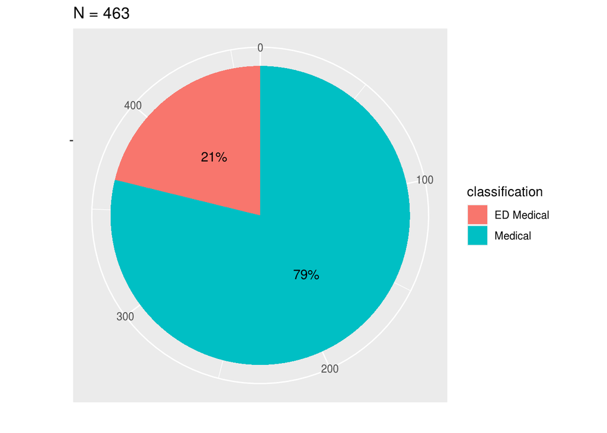

```r
snomed_stemi %>%
  dplyr::group_by(classification) %>%
  dplyr::summarise(count = n()) %>%
  dplyr::ungroup() %>%
  dplyr::mutate(per=count/sum(count)) %>%
ggplot2::ggplot(., ggplot2::aes(x="",y=count, fill=classification))+
ggplot2::geom_bar(width = 1, stat = "identity") +
  ggplot2::coord_polar("y", start=0) + ggplot2::xlab("") + ggplot2::ggtitle(paste0("N = ", nrow(snomed_stemi))) + ggplot2::ylab("") +
  ggplot2::geom_text(ggplot2::aes(label = scales::percent(per)), position = ggplot2::position_stack(vjust = 0.5))
```

We repeat the same for the diagnosis type

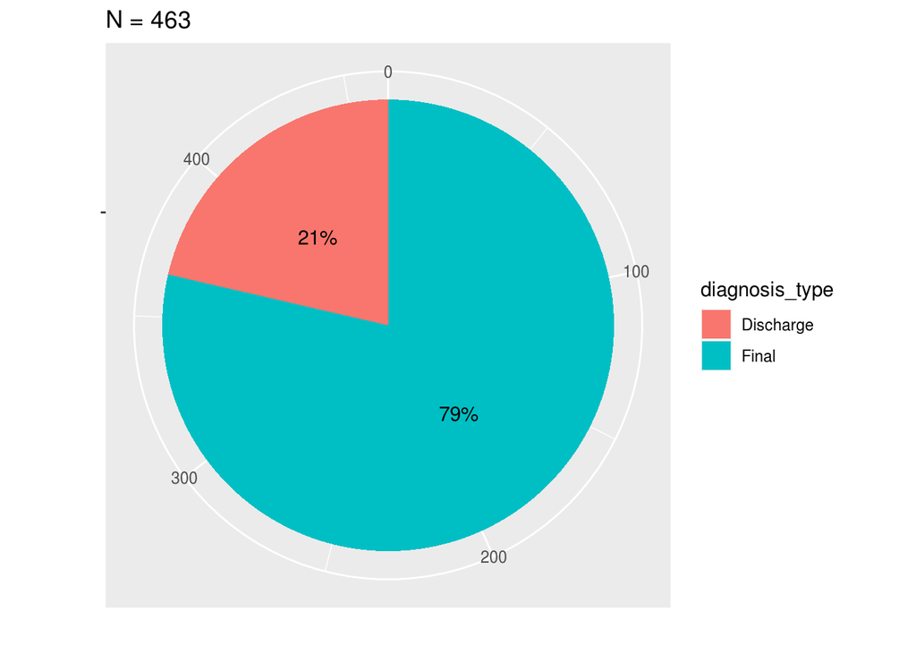

```r
snomed_stemi %>%
  dplyr::group_by(diagnosis_type) %>%
  dplyr::summarise(count = n()) %>%
  dplyr::ungroup() %>%
  dplyr::mutate(per=count/sum(count)) %>%
ggplot2::ggplot(., ggplot2::aes(x="",y=count, fill=diagnosis_type))+
ggplot2::geom_bar(width = 1, stat = "identity") +
  ggplot2::coord_polar("y", start=0) + ggplot2::xlab("") + ggplot2::ggtitle(paste0("N = ", nrow(snomed_stemi))) + ggplot2::ylab("") +
  ggplot2::geom_text(ggplot2::aes(label = scales::percent(per)), position = ggplot2::position_stack(vjust = 0.5))
```

Most *discharge* diagnoses are associated with *ED medical* and **all** *final* diagnoses is considered as a *Medical* classification.

```r
snomed_stemi %>%
  dplyr::group_by(diagnosis_type,classification) %>%
  dplyr::summarise(count = n()) %>%
  dplyr::ungroup() %>%
  knitr::kable(.,format = "html", table.attr = "style='width:50%;'") %>%
  kableExtra::kable_styling()
```

| diagnosis_type | classification | count |
| --- | --- | --- |
| Discharge | ED Medical | 98 |
| Discharge | Medical | 1 |
| Final | Medical | 364 |

We look at the difference between the time stamps of the STEMI-defined SNOMED diagnosis and their admission time to look at the delay between their admission and when the SNOMED code was registered into the system.

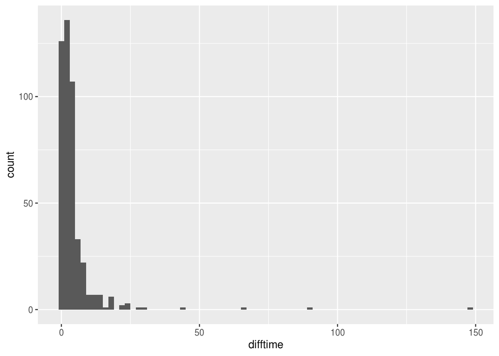

```r
test <- snomed_stemi %>%
  dplyr::left_join(encounter_rns, by = "encntr_key") %>%
  dplyr::mutate(difftime = difftime(diagnosis_start_dttm,admit_dttm, unit="days"))
ggplot2::ggplot(test, ggplot2::aes(x=difftime))+
ggplot2::geom_histogram(binwidth=2)
```

```r
knitr::kable(dplyr::summarise(test,mean=mean(difftime),
                 std=sd(difftime)),format = "html", table.attr = "style='width:50%;'") %>%
  kableExtra::kable_styling()
```

| mean | std |
| --- | --- |
| 4.31338 days | 9.563691 |

## 1.3 Confusion matrix

```r
icd10_snomed_stemi_intersect <- dplyr::intersect(icd10_stemi$encntr_key, snomed_stemi$encntr_key)

icd10_snomed_stemi_union <- dplyr::union(icd10_stemi$encntr_key, snomed_stemi$encntr_key)
message(length(unique(icd10_snomed_stemi_intersect)))
message(length(unique(icd10_snomed_stemi_union)))
```

The number of unique encounters with a STEMI-defined ICD10 code OR STEMI-defined SNOMED code (the union) is **770**

The number of unique encounters with a STEMI-defined ICD10 code AND STEMI-defined SNOMED code (the intersection) **400**

Below we show a contingency table (confusion matrix) of the ICD10 and SNOMED codes N = **770**.

```r
cm <- data.frame(encntr_key = icd10_snomed_stemi_union) %>%
  dplyr::mutate(
      ICD10 = dplyr::case_when(
          encntr_key %in% icd10_stemi$encntr_key ~ "STEMI-ICD10",
          TRUE ~ "NOT STEMI-ICD10"
        ),
      SNOMED = dplyr::case_when(
          encntr_key %in% snomed_stemi$encntr_key ~ "STEMI-SNOMED",
          TRUE ~ "NOT STEMI-SNOMED"
        ))
knitr::kable(table(cm$ICD10,cm$SNOMED),format = "html", table.attr = "style='width:70%;'") %>%
  kableExtra::kable_styling()
```

|  | NOT STEMI-SNOMED | STEMI-SNOMED |
| --- | --- | --- |
| NOT STEMI-ICD10 | 0 | 57 |
| STEMI-ICD10 | 313 | 400 |

For example, of the **770** encounters with either a STEMI ICD10 or SNOMED code, only **51.95**% have both a STEMI ICD10 *AND* STEMI SNOMED code and **40.65**% have a STEMI ICD10 but *NOT* a STEMI SNOMED code.

```r
knitr::kable(table(cm$ICD10,cm$SNOMED)/dplyr::n_distinct(icd10_snomed_stemi_union)*100,format = "html", table.attr = "style='width:70%;'") %>%
  kableExtra::kable_styling()
```

|  | NOT STEMI-SNOMED | STEMI-SNOMED |
| --- | --- | --- |
| NOT STEMI-ICD10 | 0.00000 | 7.402597 |
| STEMI-ICD10 | 40.64935 | 51.948052 |